# Assignment 7 - Part 2

Kimberly Juarez-Rico

12/8/2021

Part 2: Building Emissions, ZIPCODE 95472 for Sebastopol

The second part of the assignment focused on calculating emissions based on the energy use by parcel for Sebastopol, CA in Sonoma County. I found open data from the Sonoma County site that divides parcels into residential and commercial parcel catergories. I used 2020 data that assumes an electricity emission factor of 206 (PGE). I used June 2020 data to match SafeGraph data used in part 1.

Load necessary libraries:

```r
library(tigris)
library(dplyr)
library(tidyverse)
library(mapboxapi)
library(censusapi)
library(sf)
library(leaflet)
library(mapboxapi)
library(jsonlite)


Sys.setenv(CENSUS_KEY="4f290b276a2a5526b13d917c76884e70b99ba725")
```

Inputs PG&E data for the year 2020:

```r
pge_data <-
  2020 %>%
  map_dfr(function(yr){

    1:2 %>%
      map_dfr(function(quarter){

        c("Electric","Gas") %>%
          map_dfr(function(type){

            filename <-
              paste0(
                "PGE_",
                yr,
                "_Q",
                quarter,
                "_",
                type,
                "UsageByZip.csv"
              )

            temp <- read_csv(filename)

            temp <-
              temp %>%
              rename_all(toupper) %>%
              mutate(
                TOTALKBTU = ifelse(
                  substr(CUSTOMERCLASS,1,1) == "E",
                  TOTALKWH * 3.412,
                  TOTALTHM * 99.976
                ),
                TOTALTCO2E = ifelse(
                  substr(CUSTOMERCLASS,1,1) == "E",
                  TOTALKWH/1000 * 206 * 0.000453592,
                  TOTALTHM * 0.00531
                )
              ) %>%
              select(
                ZIPCODE,
                YEAR,
                MONTH,
                CUSTOMERCLASS,
                TOTALKBTU,
                TOTALTCO2E,
                TOTALCUSTOMERS
              )

          })

      })

  })
```

Filters ZCTAS data for the US, then Sonoma County, and then Sebastopol:

```r
us_zips <-
  zctas(cb = T, progress_bar = F)

sonoma_zips <-
  us_zips %>%
  st_centroid() %>%
  .[counties("CA", cb = T, progress_bar = F) %>% filter(NAME == "Sonoma"), ] %>%
  st_set_geometry(NULL) %>%
  left_join(us_zips %>% select(GEOID10)) %>%
  st_as_sf()

seb_zips<-
  sonoma_zips %>%
  filter(ZCTA5CE10 == 95472)
```

Filters Sebastopol PG&E data from the total PG&E data set to electric and gas residential use and commercial and gas residential use:

```r
seb_pge_data <-
  pge_data %>%
  filter(ZIPCODE %in% seb_zips$ZCTA5CE10) %>%
  filter(CUSTOMERCLASS %in% c(
    "Elec- Commercial",
    "Elec- Residential",
    "Gas- Commercial",
    "Gas- Residential"
  )) %>%
  mutate(
    UseCodType = substr(CUSTOMERCLASS,0,20)
  ) %>%
  group_by(ZIPCODE, UseCodType, MONTH, YEAR) %>%
  summarize(
    TOTALKBTU = sum(TOTALKBTU, na.rm=T),
    TOTALTCO2E = sum(TOTALTCO2E, na.rm=T),
    TOTALCUSTOMERS = mean(TOTALCUSTOMERS, na.rm=T)
  ) %>%
  group_by(ZIPCODE,UseCodType, MONTH) %>%
  summarize_at(
    vars(TOTALKBTU,TOTALTCO2E,TOTALCUSTOMERS),
    sum,
    na.rm=T
  )
```

Filters energy data for just the month of June 2020:

```r
seb_june_2020 <-
  seb_pge_data %>%
  filter(MONTH == 6)
```

Summarizes energy use by KBTUs and CO2E emissions:

```r
seb_pge_june_2020 <-
  seb_june_2020%>%
group_by(UseCodType,TOTALKBTU, TOTALTCO2E)%>%
 summarize(
  TOTALKBTU = sum(TOTALKBTU, na.rm = T),
  TOTALTCO2E = sum(TOTALTCO2E, na.rm = T)
  )
```

Creates a map of June 2020 energy use in Sebastopol:

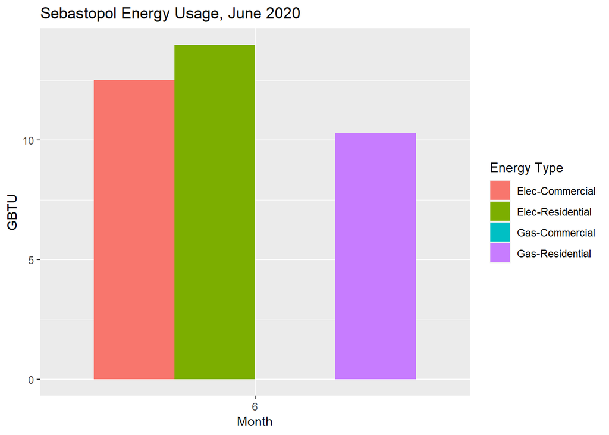

```r
ggplot(
  seb_june_2020,
  aes(
    x = as.factor(MONTH),
    y = TOTALKBTU/1000000
  )
) +
  geom_bar(stat = "identity", aes(fill = UseCodType), position = "dodge") +
  labs(x = "Month", y = "GBTU", title = "Sebastopol Energy Usage, June 2020") +
  scale_fill_discrete(name="Energy Type",labels = c("Elec-Commercial",
                                                    "Elec-Residential",
                                                    "Gas-Commercial",
                                                    "Gas-Residential"))
```

Creates a map of June 2020 emissions in Sebastopol:

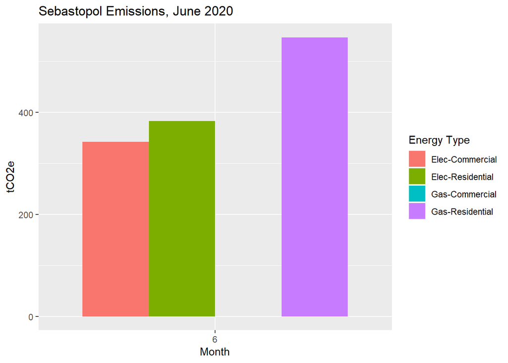

```r
ggplot(
  seb_june_2020,
  aes(
    x = as.factor(MONTH),
    y = TOTALTCO2E
  )
) +
  geom_bar(stat = "identity", aes(fill = UseCodType), position = "dodge") +
  labs(x = "Month", y = "tCO2e", title = "Sebastopol Emissions, June 2020") +
  scale_fill_discrete(name="Energy Type",labels = c("Elec-Commercial",
                                                    "Elec-Residential",
                                                    "Gas-Commercial",
                                                    "Gas-Residential"))
```

I was able to find parcel data for Sonoma County by using the County of Sonoma website that has open source parcel data for direct download. This is probably due to the fact that the area is prone to wildfires so openly available parcel data may be requested often, but I operated under the assumption that parcels have not changed in 2017 for the purpose of creating an energy analysis.

Bring in parcel data:

```r
soco_parcel_data <- read_csv("Sonoma_County_Parcels.csv")

soco_parcel_data
```

```
## # A tibble: 186,563 x 41
##    OBJECTID APN   LevelNum Subdivision Asmt  Taxability TxbltyFull TxbltyDes
##       <dbl> <chr>    <dbl> <chr>       <chr>      <dbl> <chr>      <chr>
##  1        1 001-~        1 <NA>        0013~          1 000        NORMAL O~
##  2        2 001-~        1 <NA>        0013~          1 060        TAX POST~
##  3        3 001-~        1 <NA>        0013~          1 000        NORMAL O~
##  4        4 001-~        1 <NA>        0013~          1 000        NORMAL O~
##  5        5 001-~        1 <NA>        0013~          1 012        LOW VALU~
##  6        6 001-~        1 <NA>        0013~          1 000        NORMAL O~
##  7        7 001-~        1 <NA>        0010~          2 023        NON-TAXA~
##  8        8 001-~        1 <NA>        0010~          2 023        NON-TAXA~
##  9        9 001-~        1 <NA>        0010~          1 000        NORMAL O~
## 10       10 001-~        1 <NA>        0010~          1 000        NORMAL O~
## # ... with 186,553 more rows, and 33 more variables: TRA <chr>, TRADesc <chr>,
## #   UseCode <chr>, UseCodDesc <chr>, UseCodType <chr>, LndSizAcre <dbl>,
## #   LndSizSqft <dbl>, MailDBACO <chr>, MailStrAdd <chr>, MailCtySta <chr>,
## #   MailZip5 <chr>, MailZip4 <chr>, MailAdr1 <chr>, MailAdr2 <chr>,
## #   MailAdr3 <chr>, MailAdr4 <lgl>, SitusFrm1 <chr>, SitusFrm2 <chr>,
## #   V601RollYr <dbl>, V601Land <dbl>, V601Strt <dbl>, V601Fix <dbl>,
## #   V601FxRP <dbl>, V601Grw <dbl>, V601TotalI <dbl>, V601PPBus <dbl>,
## #   V601PPMB <dbl>, V601ExHome <dbl>, V601ExOthr <dbl>, V601NetVal <dbl>,
## #   V601ExptCO <chr>, Shape__Area <dbl>, Shape__Length <dbl>
```

Filter to just Sebastopol by city name, building type, and 95472 zip code:

```r
seb_parcel_filter <-
  soco_parcel_data%>%
  select(
    OBJECTID, UseCodType,TRADesc, LndSizAcre, LndSizSqft, MailCtySta, MailZip5,
    SitusFrm1
  )%>%
  filter(
    TRADesc %in% c("Sebastopol"),

    UseCodType %in%
      c(
        "Residential",
        "Commercial"),

    MailZip5 %in% c("95472")
  )

seb_parcel_filter
```

```
## # A tibble: 2,158 x 8
##    OBJECTID UseCodType TRADesc LndSizAcre LndSizSqft MailCtySta MailZip5
##       <dbl> <chr>      <chr>        <dbl>      <dbl> <chr>      <chr>
##  1     4307 Residenti~ Sebast~      0.69       30160 SEBASTOPO~ 95472
##  2     4314 Residenti~ Sebast~      0.17        7500 SEBASTOPO~ 95472
##  3     4315 Residenti~ Sebast~      0.17        7740 SEBASTOPO~ 95472
##  4     4316 Residenti~ Sebast~      0.31       13870 SEBASTOPO~ 95472
##  5     4317 Residenti~ Sebast~      0.34       14820 SEBASTOPO~ 95472
##  6     4318 Residenti~ Sebast~      0.210       9526 SEBASTOPO~ 95472
##  7     4319 Residenti~ Sebast~      0           7699 SEBASTOPO~ 95472
##  8     4320 Residenti~ Sebast~      0           6240 SEBASTOPO~ 95472
##  9     4402 Residenti~ Sebast~      0.430      19000 SEBASTOPO~ 95472
## 10     4403 Commercial Sebast~     10.8            0 SEBASTOPO~ 95472
## # ... with 2,148 more rows, and 1 more variable: SitusFrm1 <chr>
```

Filters the parcels to only residential building area:

```r
seb_parcels_res <-
  seb_parcel_filter %>%
  filter(
    TRADesc %in% c("Sebastopol"),

    UseCodType %in%
      c("Residential"),

    MailZip5 %in% c("95472")
  )

seb_parcels_res
```

```
## # A tibble: 1,942 x 8
##    OBJECTID UseCodType TRADesc LndSizAcre LndSizSqft MailCtySta MailZip5
##       <dbl> <chr>      <chr>        <dbl>      <dbl> <chr>      <chr>
##  1     4307 Residenti~ Sebast~      0.69       30160 SEBASTOPO~ 95472
##  2     4314 Residenti~ Sebast~      0.17        7500 SEBASTOPO~ 95472
##  3     4315 Residenti~ Sebast~      0.17        7740 SEBASTOPO~ 95472
##  4     4316 Residenti~ Sebast~      0.31       13870 SEBASTOPO~ 95472
##  5     4317 Residenti~ Sebast~      0.34       14820 SEBASTOPO~ 95472
##  6     4318 Residenti~ Sebast~      0.210       9526 SEBASTOPO~ 95472
##  7     4319 Residenti~ Sebast~      0           7699 SEBASTOPO~ 95472
##  8     4320 Residenti~ Sebast~      0           6240 SEBASTOPO~ 95472
##  9     4402 Residenti~ Sebast~      0.430      19000 SEBASTOPO~ 95472
## 10     4404 Residenti~ Sebast~      0.11        4850 SEBASTOPO~ 95472
## # ... with 1,932 more rows, and 1 more variable: SitusFrm1 <chr>
```

Filters the parcels to only commercial building area:

```r
seb_parcels_com <-
  seb_parcel_filter %>%
  filter(
    TRADesc %in% c("Sebastopol"),

    UseCodType %in%
      c("Commercial"),

    MailZip5 %in% c("95472")
  )

seb_parcels_com
```

```
## # A tibble: 216 x 8
##    OBJECTID UseCodType TRADesc LndSizAcre LndSizSqft MailCtySta MailZip5
##       <dbl> <chr>      <chr>        <dbl>      <dbl> <chr>      <chr>
##  1     4403 Commercial Sebast~     10.8            0 SEBASTOPO~ 95472
##  2     4855 Commercial Sebast~      5.47           0 SEBASTOPO~ 95472
##  3     4893 Commercial Sebast~      4.21           0 SEBASTOPO~ 95472
##  4     4915 Commercial Sebast~      0.920          0 SEBASTOPO~ 95472
##  5     5447 Commercial Sebast~      0.180       7950 SEBASTOPO~ 95472
##  6     5458 Commercial Sebast~      0          17424 SEBASTOPO~ 95472
##  7     5467 Commercial Sebast~      0.38       16680 SEBASTOPO~ 95472
##  8     5468 Commercial Sebast~      0.510      22240 SEBASTOPO~ 95472
##  9     5470 Commercial Sebast~      0.710          0 SEBASTOPO~ 95472
## 10     5474 Commercial Sebast~      0.17        7500 SEBASTOPO~ 95472
## # ... with 206 more rows, and 1 more variable: SitusFrm1 <chr>
```

Filters the total residential parcel data to square feet:

```r
seb_parcel_final_res <-
seb_parcels_res%>%
summarize(
  TotalSqFt = sum(LndSizSqft, na.rm = T))
```

```r
seb_parcel_final_com <-
seb_parcels_com%>%
summarize(
  TotalSqFt = sum(LndSizSqft, na.rm = T))
```

Total commercial electricity use per parcel square feet in Sebastopol for the month of June 2020:

```r
elec_com_use_per_sqft = seb_pge_june_2020[1,2] / seb_parcel_final_com[1,1]
```

Total commercial emissions per parcel square feet in Sebastopol for the month of June 2020:

```r
elec_com_emissions_per_sqft = seb_pge_june_2020[1,3] / seb_parcel_final_com[1,1]
```

Total residential electricity use per parcel square feet in Sebastopol for the month of June 2020:

```r
elec_res_use_per_sqft = seb_pge_june_2020[2,2] / seb_parcel_final_res[1,1]
```

Total residential electricity emissions per parcel square feet in Sebastopol for the month of June 2020:

```r
elec_res_emissions_per_sqft = seb_pge_june_2020[2,3] / seb_parcel_final_res[1,1]
```

```r
gas_com_use_per_sqft = seb_pge_june_2020[3,2] / seb_parcel_final_com[1,1]
```

Total commercial gas emissions per parcel square feet in Sebastopol for the month of June 2020:

```r
gas_com_emissions_per_sqft = seb_pge_june_2020[3,3] / seb_parcel_final_com[1,1]
```

Total residential gas use per parcel square feet in Sebastopol for the month of June 2020:

```r
gas_res_use_per_sqft = seb_pge_june_2020[4,2] / seb_parcel_final_res[1,1]
```

Total residential gas emissions per parcel square feet in Sebastopol for the month of June 2020:

```r
gas_res_emissions_per_sqft = seb_pge_june_2020[4,3] / seb_parcel_final_res[1,1]
```

The total commercial electricity use in Sebastopol per parcel square foot for the month of June 2020 is 6.596244 kBTU. The total commercial electricity emissions in Sebastopol per parcel square foot for the month of June 2020 is 0.0001806427 tCO2E.

The total residential electricity use in Sebastopol per parcel square foot for the month of June 2020 is 0.8678829 kBTU. The total residential electricity emissions in Sebastopol per parcel square foot for the month of June 2020 is 2.376757e-05 tCO2E.

The total commercial gas use in Sebastopol per parcel square foot for the month of June 2020 is 0 kBTU. The total commercial gas emissions in Sebastopol per parcel square foot for the month of June 2020 is 0 tCO2E.

The total residential gas use in Sebastopol per parcel square foot for the month of June 2020 is 0.6395403 kBTU. The total residential gas emissions in Sebastopol per parcel square foot for the month of June 2020 is 3.396774e-05 tCO2E.

Sources Used:

https://stanfordfuturebay.github.io/course/introduction.html

https://sonomacounty.ca.gov/PRMD/Administration/GIS/Geographical-Information-Systems/